# Medical_Insurance_Cost_Prediction_using_Machine_Learning

**This tutorial is written by Habibur Rahman, Graduate Research Assistant, School of Materials Engineering, Purdue University, West Lafayette, IN email: msehabibur@purdue.edu**

In this tutorial, I will illustrate how to utilize standard machine learning (ML) regression techniques, specifically Random Forest (RF) and Neural Network (NN), to construct models for predicting insurance costs based on various factors such as age, sex, BMI, number of children, smoking habits, and region. Additionally, I will demonstrate how to optimize hyperparameters using both grid search CV and randomized search with 5-fold cross-validation. Furthermore, I will conduct a Pearson correlation matrix analysis to identify any underlying relationships within the dataset.

```python
import numpy as np
import pandas as pd
import matplotlib.pyplot as plt
import seaborn as sns
from sklearn.model_selection import train_test_split
from sklearn.linear_model import LinearRegression
from sklearn import metrics
import matplotlib.pyplot as plt
```

```python
# loading the data from csv file to a Pandas DataFrame
data = pd.read_csv('/content/drive/MyDrive/DeepMSE/Medical_Insurance_Cost_Prediction_using_Machine_Learning/insurance.csv')
```

```python
data.head()
#data.shape
#data.isnull().sum()
#data.describe()
```

|  | age | sex | bmi | children | smoker | region | charges |
| --- | --- | --- | --- | --- | --- | --- | --- |
| 0 | 19 | female | 27.900 | 0 | yes | southwest | 16884.92400 |
| 1 | 18 | male | 33.770 | 1 | no | southeast | 1725.55230 |
| 2 | 28 | male | 33.000 | 3 | no | southeast | 4449.46200 |
| 3 | 33 | male | 22.705 | 0 | no | northwest | 21984.47061 |
| 4 | 32 | male | 28.880 | 0 | no | northwest | 3866.85520 |

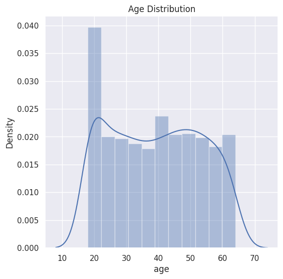

```python
# distribution of age value
sns.set()
plt.figure(figsize=(6,6))
sns.distplot(data['age'])
plt.title('Age Distribution')
plt.show()
```

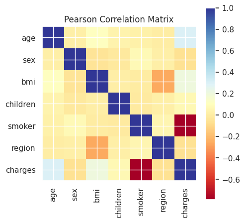

```python
import pandas as pd
import matplotlib.pyplot as plt

# Encoding categorical columns
data.replace({'sex': {'male': 0, 'female': 1}, 'smoker': {'yes': 0, 'no': 1},
              'region': {'southeast': 0, 'southwest': 1, 'northeast': 2, 'northwest': 3}},
             inplace=True)

# Calculating the Pearson correlation matrix
correlation_matrix = data.corr()
# Plotting the correlation matrix
# Creates a new figure with a specific size of 5 inches (width) and 5 inches (height).
plt.figure(figsize=(5, 5))
# Displays the correlation matrix as an image using the imshow function. The correlation_matrix variable represents the correlation values between different features.
# The cmap parameter specifies the colormap to be used, and 'RdYlBu' is a colormap that ranges from red (negative correlation) to blue (positive correlation).
# The interpolation parameter is set to 'none', indicating no interpolation between the pixels.
plt.imshow(correlation_matrix, cmap='RdYlBu', interpolation='none')
# Adds a colorbar to the plot, which provides a visual representation of the correlation values.
plt.colorbar()
# Sets the x-axis tick locations and labels. The range(len(correlation_matrix.columns)) generates a sequence of numbers from 0 to the number of columns in the correlation matrix.
# correlation_matrix.columns provides the column labels of the correlation matrix. The rotation=90 parameter rotates the x-axis labels by 90 degrees for better readability.
plt.xticks(range(len(correlation_matrix.columns)), correlation_matrix.columns, rotation=90)
# Sets the y-axis tick locations and labels, similar to the plt.xticks() function.
plt.yticks(range(len(correlation_matrix.columns)), correlation_matrix.columns)
# Sets the title of the plot to "Pearson Correlation Matrix".
plt.title('Pearson Correlation Matrix')
plt.show()
```

Now, let's build up a RF model on the given data set using 5 fold CV and Grid search CV for optimzing the hyperparamters set.

```python
import numpy as np
import pandas as pd
from sklearn.ensemble import RandomForestRegressor
from sklearn.model_selection import GridSearchCV, train_test_split
from sklearn.metrics import mean_squared_error

# Loading the dataset
data = data = pd.read_csv('/content/drive/MyDrive/DeepMSE/Medical_Insurance_Cost_Prediction_using_Machine_Learning/insurance.csv')

# encoding sex column
data.replace({'sex':{'male':0,'female':1}}, inplace=True)

3 # encoding 'smoker' column
data.replace({'smoker':{'yes':0,'no':1}}, inplace=True)

# encoding 'region' column
data.replace({'region':{'southeast':0,'southwest':1,'northeast':2,'northwest':3}}, inplace=True)

# Splitting the dataset into training and testing sets
X = data.drop('charges', axis=1)  # Features
y = data['charges']  # Target variable
X_train, X_test, y_train, y_test = train_test_split(X, y, test_size=0.3, random_state=42)

# Creating a Random Forest Regression model
rf = RandomForestRegressor(random_state=42)

# Defining the hyperparameter grid
param_grid = {
    'n_estimators': [50, 100, 150],
    'max_depth': [None, 5, 10],
    'min_samples_split': [2, 5, 10],
    'min_samples_leaf': [1, 2, 4]
}

# Performing grid search cross-validation
# It specifies the estimator object, which is the model or algorithm that will be optimized during the grid search.
# In this case, the estimator is rf, which is an instance of the RandomForestRegressor.
# It is a dictionary or a list of dictionaries that defines the hyperparameter grid to be searched.
# Each key in the dictionary represents a hyperparameter name, and the corresponding value(s) represent the values to be searched for that hyperparameter.
# This allows us to define multiple combinations of hyperparameters to be evaluated.
# It specifies the number of cross-validation folds to be used during the grid search.
# In this case, cv=5 indicates a 5-fold cross-validation, where the dataset is divided into 5 equal parts, and the model is trained and evaluated 5 times,
# with each part serving as the validation set once.
# It specifies the scoring metric used to evaluate the performance of each combination of hyperparameters.
# In this case, 'neg_mean_squared_error' is used as the scoring metric.
# The negative mean squared error is a common metric used in regression problems, where lower values indicate better performance.
grid_search = GridSearchCV(estimator=rf, param_grid=param_grid, cv=5, scoring='neg_mean_squared_error')
grid_search.fit(X_train, y_train)

# Retrieving the best model
best_model = grid_search.best_estimator_

# Making predictions on the test set using the best model
y_pred = best_model.predict(X_test)

# Evaluating the model's performance
mse = mean_squared_error(y_test, y_pred)
rmse = np.sqrt(mse)
print('Root Mean Squared Error:', rmse)

# Printing the best hyperparameters
print('Best Hyperparameters:', grid_search.best_params_)
# Calculate the feature importances
```

```
Root Mean Squared Error: 4315.811169628229
Best Hyperparameters: {'max_depth': 5, 'min_samples_leaf': 4, 'min_samples_split': 10, 'n_estimators': 150}
```

By performing the grid search cross-validation, the code will evaluate the performance of different combinations of hyperparameters for the RandomForestRegressor model using the specified scoring metric. It will then select the best combination of hyperparameters that yields the lowest mean squared error on average across the cross-validation folds. This helps in finding the optimal set of hyperparameters for the RandomForestRegressor model, improving its performance on unseen data.

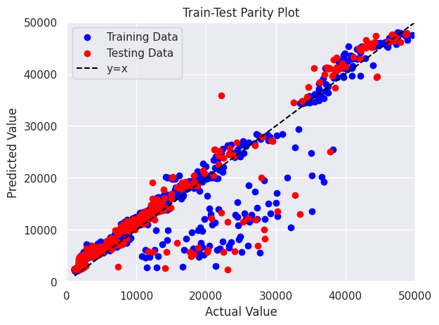

```python
import matplotlib.pyplot as plt

# Making predictions on the training set using the best model
y_train_pred = best_model.predict(X_train)

# Plotting the train-test parity plot
plt.scatter(y_train, y_train_pred, color='blue', label='Training Data')
plt.scatter(y_test, y_pred, color='red', label='Testing Data')
plt.plot([min(y_train.min(), y_test.min()), max(y_train.max(), y_test.max())],
         [min(y_train.min(), y_test.min()), max(y_train.max(), y_test.max())],
         color='black', linestyle='--', label='y=x')
plt.xlabel('Actual Value')
plt.ylabel('Predicted Value')
plt.title('Train-Test Parity Plot')
plt.legend()
plt.xlim(0, 50000)  # Set X range
plt.ylim(0, 50000)  # Set Y range
plt.show()
```

Now let's build a predictive model

```python
input_data = (27,1,25.74,0,1,1)

# changing input_data to a numpy array
input_data_as_numpy_array = np.asarray(input_data)

# reshape the array
input_data_reshaped = input_data_as_numpy_array.reshape(1,-1)

# The argument (1, -1) passed to the reshape() function specifies the desired shape of the array.
# The 1 indicates that we want the resulting array to have 1 row.
# The -1 is a placeholder that allows NumPy to automatically determine the appropriate number of columns based on the size of the input data.

prediction = best_model.predict(input_data_reshaped)
print(prediction)

print('The insurance cost is USD ', prediction[0])
```

```
[4650.09687274]
The insurance cost is USD  4650.096872740438
```

Now, let's build up a RF model on the given data set using 5 fold CV and Randomized search CV for optimzing the hyperparamters set.

```python
import numpy as np
import pandas as pd
from sklearn.ensemble import RandomForestRegressor
from sklearn.model_selection import RandomizedSearchCV, train_test_split
from sklearn.metrics import mean_squared_error
from sklearn.metrics import r2_score

# Loading the dataset
data = pd.read_csv('/content/drive/MyDrive/DeepMSE/Medical_Insurance_Cost_Prediction_using_Machine_Learning/insurance.csv')

# Encoding sex column
data.replace({'sex': {'male': 0, 'female': 1}}, inplace=True)

# Encoding 'smoker' column
data.replace({'smoker': {'yes': 0, 'no': 1}}, inplace=True)

# Encoding 'region' column
data.replace({'region': {'southeast': 0, 'southwest': 1, 'northeast': 2, 'northwest': 3}}, inplace=True)

# Splitting the dataset into training and testing sets
X = data.drop('charges', axis=1)  # Features
y = data['charges']  # Target variable
X_train, X_test, y_train, y_test = train_test_split(X, y, test_size=0.3, random_state=42)

# Creating a Random Forest Regression model
rf = RandomForestRegressor(random_state=42)

# Defining the hyperparameter grid
param_grid = {
    'n_estimators': np.arange(50, 151, 50),
    'max_depth': [None, 5, 10],
    'min_samples_split': [2, 5, 10],
    'min_samples_leaf': [1, 2, 4]
}

#n_iter: It specifies the number of parameter settings that are sampled from the specified distributions.
#In other words, it determines how many different combinations of hyperparameters are evaluated during the randomized search.
#In this case, n_iter=10 means that 10 random combinations of hyperparameters will be tested.

# Performing randomized search cross-validation
random_search = RandomizedSearchCV(estimator=rf, param_distributions=param_grid, cv=5, scoring='neg_mean_squared_error', n_iter=10)
random_search.fit(X_train, y_train)

# Retrieving the best model
best_model = random_search.best_estimator_

# Making predictions on the test set using the best model
y_pred = best_model.predict(X_test)

# Evaluating the model's performance
mse = mean_squared_error(y_test, y_pred)
rmse = np.sqrt(mse)
r2 = r2_score(y_test, y_pred)

# Printing the evaluation metrics
print('Root Mean Squared Error:', rmse)
print('R-squared:', r2)

# Printing the best hyperparameters
print('Best Hyperparameters:', random_search.best_params_)
```

```
Root Mean Squared Error: 4322.240712461866
R-squared: 0.8725875330988603
Best Hyperparameters: {'n_estimators': 50, 'min_samples_split': 2, 'min_samples_leaf': 4, 'max_depth': 5}
```

[figure not shown]

```python
import matplotlib.pyplot as plt

# Making predictions on the training set using the best model
y_train_pred = best_model.predict(X_train)

# Plotting the train-test parity plot
plt.scatter(y_train, y_train_pred, color='blue', label='Training Data')
plt.scatter(y_test, y_pred, color='red', label='Testing Data')
plt.plot([min(y_train.min(), y_test.min()), max(y_train.max(), y_test.max())],
         [min(y_train.min(), y_test.min()), max(y_train.max(), y_test.max())],
         color='black', linestyle='--', label='y=x')
plt.xlabel('Actual Value')
plt.ylabel('Predicted Value')
plt.title('Train-Test Parity Plot')
plt.legend()
plt.xlim(0, 50000)  # Set X range
plt.ylim(0, 50000)  # Set Y range
plt.show()
```

Removing outliers from a ML dataset can help improve the model's performance and prevent it from being overly influenced by extreme values. Here are some common approaches to remove outliers. Statistical methods: One approach is to use statistical methods to identify outliers based on the distribution of the data. You can calculate the z-scores or use the interquartile range (IQR) to detect data points that fall outside a certain threshold. Data points beyond a certain number of standard deviations from the mean or outside a specific range of the IQR can be considered outliers and removed from the dataset. Visualization techniques: Plotting the data can help identify outliers visually. Box plots, scatter plots, and histograms can reveal any data points that deviate significantly from the overall pattern. Observing data points that lie far away from the bulk of the data or exhibit unusual patterns can indicate potential outliers. Domain knowledge: Your knowledge about the domain can guide you in identifying outliers. For example, if you know that a certain feature or target variable should fall within a specific range, any data points outside that range can be considered outliers. Ensemble methods: Ensemble methods, such as Random Forests, are less sensitive to outliers compared to some other models. By using an ensemble model, the impact of outliers can be reduced as the model aggregates predictions from multiple trees. Winsorization or trimming: Instead of removing outliers, you can choose to Winsorize or trim the data. Winsorization involves replacing extreme values with the nearest value within a certain percentile. Trimming simply involves removing the extreme values without replacement. It's important to note that the decision to remove outliers should be made carefully, as outliers may contain valuable information or represent genuine anomalies in the data. It's advisable to analyze the impact of outlier removal on the model's performance and consider the specific context and goals of the analysis before deciding to remove outliers. The Z-score, also known as the standard score, is a statistical measure that quantifies how far away a particular data point is from the mean of a distribution. It is used to normalize and compare data points from different distributions. The formula to calculate the Z-score for a data point x in a distribution with mean μ and standard deviation σ is:

Z = (x - μ) / σ

The Z-score tells us how many standard deviations a data point is away from the mean. A positive Z-score indicates that the data point is above the mean, while a negative Z-score indicates that the data point is below the mean. By calculating the Z-scores for all the data points in a dataset, we can identify outliers. Typically, data points with a Z-score greater than a certain threshold (e.g., 2 or 3) are considered outliers and may be removed from the dataset or treated separately in the analysis. Removing outliers helps in reducing the influence of extreme values on statistical analysis or model fitting.

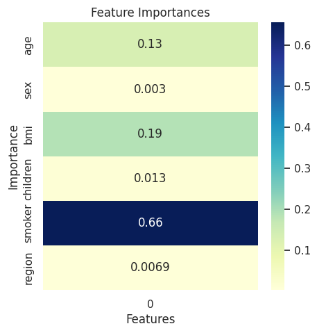

```python
import pandas as pd
import seaborn as sns
import matplotlib.pyplot as plt
from sklearn.ensemble import RandomForestRegressor

# Assuming `X` is the DataFrame containing the features
# Assuming `y` is the target variable
# Assuming `X_train` and `y_train` are the training data

# Creating a Random Forest Regression model
rf = RandomForestRegressor(n_estimators=100, min_samples_leaf=4, random_state=42)

# Training the model
rf.fit(X_train, y_train)

# Calculate the feature importances
importances = pd.Series(rf.feature_importances_, index=X.columns)

# Create a heatmap of the feature importances
plt.figure(figsize=(5, 5))
sns.heatmap(importances.to_frame(), annot=True, cmap='YlGnBu')
plt.title('Feature Importances')
plt.xlabel('Features')
plt.ylabel('Importance')
plt.show()
```

Now, let's build up a NN model on the given data set using 5 fold CV and Grid search CV for optimzing the hyperparamters set.

```python
import numpy as np
import pandas as pd
from sklearn.model_selection import GridSearchCV, train_test_split
from sklearn.preprocessing import LabelEncoder, StandardScaler
from sklearn.neural_network import MLPRegressor
from sklearn.metrics import mean_squared_error
from sklearn.exceptions import ConvergenceWarning
import warnings

# Suppress ConvergenceWarning
warnings.filterwarnings("ignore", category=ConvergenceWarning)

# Loading the dataset
data = pd.read_csv('/content/drive/MyDrive/DeepMSE/Medical_Insurance_Cost_Prediction_using_Machine_Learning/insurance.csv')

# Encoding categorical columns
encoder = LabelEncoder()
data['sex'] = encoder.fit_transform(data['sex'])
data['smoker'] = encoder.fit_transform(data['smoker'])
data['region'] = encoder.fit_transform(data['region'])

# Splitting the dataset into training and testing sets
X = data.drop('charges', axis=1)  # Features
y = data['charges']  # Target variable
X_train, X_test, y_train, y_test = train_test_split(X, y, test_size=0.3, random_state=42)

# Scaling the features
scaler = StandardScaler()
X_train_scaled = scaler.fit_transform(X_train)
X_test_scaled = scaler.transform(X_test)

# Creating a Neural Network Regression model
nn = MLPRegressor(random_state=42, max_iter=1000)  # Increased max_iter

# Defining the hyperparameter grid
param_grid = {
    'hidden_layer_sizes': [(100,), (50, 50)],
    'activation': ['relu', 'tanh'],
    'alpha': [0.0001, 0.001, 0.01],
    'learning_rate': ['constant', 'adaptive'],
    'max_iter': [1000]  # Increased max_iter for convergence
}

# Performing grid search cross-validation
grid_search = GridSearchCV(estimator=nn, param_grid=param_grid, cv=5, scoring='neg_mean_squared_error')
grid_search.fit(X_train_scaled, y_train)

# Retrieving the best model
best_model = grid_search.best_estimator_

# Making predictions on the test set using the best model
y_pred = best_model.predict(X_test_scaled)

# Evaluating the model's performance
mse = mean_squared_error(y_test, y_pred)
rmse = np.sqrt(mse)
print('Root Mean Squared Error:', rmse)

# Printing the best hyperparameters
print('Best Hyperparameters:', grid_search.best_params_)
```

```
Root Mean Squared Error: 5357.329693518369
Best Hyperparameters: {'activation': 'relu', 'alpha': 0.001, 'hidden_layer_sizes': (50, 50), 'learning_rate': 'constant', 'max_iter': 1000}
```

The difference in performance between a NN model and a RF model can be attributed to several factors. Here are some possible reasons why the NN model may be performing poorly compared to the RF model. Insufficient Training Data: NN typically require a large amount of training data to generalize well. If the dataset used for training the NN model is small, it may lead to overfitting, where the model becomes too specialized to the training data and performs poorly on unseen data. RF, on the other hand, can handle smaller datasets more effectively as they aggregate multiple decision trees. Improper Hyperparameter Tuning: NN have various hyperparameters that need to be tuned, such as the number of hidden layers, the number of neurons in each layer, learning rate, activation functions, etc. If the hyperparameters are not properly tuned, it can lead to suboptimal performance. RF, on the other hand, have fewer hyperparameters to tune, making them relatively easier to optimize. Feature Engineering: NN often require careful feature engineering to extract relevant information from the data. If the input features are not properly preprocessed or selected, it can impact the model's performance. RF, in contrast, are capable of handling raw or less processed data and can automatically learn feature importance. Sensitivity to Initial Conditions: NN are sensitive to initial conditions and can get stuck in local optima during the training process. The model's performance heavily depends on the initialization of the weights and biases. RF, being an ensemble method, are less prone to getting stuck in local optima and can provide more stable predictions. Interpretability: RF offer better interpretability compared to NN. RF provide feature importances, which can help understand the contribution of each feature to the model's predictions. This interpretability aspect can be beneficial for debugging and understanding the model's behavior. It's important to note that the performance of different ML models can vary depending on the dataset and problem at hand. While NN are known for their ability to capture complex patterns in the data, they may not always be the best choice for every problem. Evaluating and comparing the performance of different models on various metrics and understanding the specific characteristics of the dataset are essential steps in choosing the most suitable model.

```python
%%shell
jupyter nbconvert --to html /content/Medical_Insurance_Cost_Prediction_using_Machine_Learning.ipynb
```

```
[NbConvertApp] Converting notebook /content/Medical_Insurance_Cost_Prediction_using_Machine_Learning.ipynb to html
[NbConvertApp] Writing 975392 bytes to /content/Medical_Insurance_Cost_Prediction_using_Machine_Learning.html
```